# O mesmo modelo em scikit-learn

Lasso e floresta aleatória para a oferta de ônibus da SPTrans

Autor

Lab 2: Prática Avançada em Data Science e Visualização, PADS Insper

**NotaDocumento irmão**

Este arquivo tem um par idêntico em R, `tidymodels.qmd`. Mesma pergunta, mesmos dados, mesmos dois modelos, mesma sequência de seções. A ideia é abrir os dois lado a lado e ler a mesma etapa nas duas linguagens.

## A pergunta e os dados

Queremos prever o **headway**: o intervalo programado entre dois ônibus da mesma linha, em segundos. Cada registro é uma combinação de linha, sentido e faixa horária, montada a partir do GTFS da SPTrans cruzado com a API Olho Vivo.

```python
import numpy as np
import pandas as pd
from plotnine import *
from sklearn.compose import ColumnTransformer
from sklearn.ensemble import RandomForestRegressor
from sklearn.impute import SimpleImputer
from sklearn.linear_model import Lasso
from sklearn.metrics import mean_absolute_error, r2_score, root_mean_squared_error
from sklearn.model_selection import GridSearchCV, GroupKFold, train_test_split
from sklearn.pipeline import Pipeline
from sklearn.preprocessing import OneHotEncoder, StandardScaler

SEMENTE = 42
```

```python
dados = pd.read_csv("dados/viagens.csv.gz", low_memory=False)

numericas = [
    "hora_inicio",
    "n_paradas",
    "extensao_km",
    "duracao_min",
    "velocidade_kmh",
    "paradas_por_km",
    "dist_centro_origem_km",
    "dist_centro_destino_km",
    "n_linhas_origem",
    "n_linhas_destino",
    "pct_paradas_corredor",
]
categoricas = [
    "periodo_dia",
    "tipo_dia",
    "sentido",
    "area_operacao",
    "tipo_linha",
    "corredor_principal",
]

# CSV não guarda tipo: uma coluna categórica só com números volta como int e o
# OneHotEncoder recusa a mistura. Em R, `factor` resolve isso sozinho.
for coluna in categoricas:
    dados[coluna] = dados[coluna].where(dados[coluna].isna(), dados[coluna].astype(str))

X = dados[numericas + categoricas]
y = dados["headway_seg"].astype(float)
grupos = dados["route_id"]

print(f"{len(dados):,} registros | {grupos.nunique():,} linhas de ônibus")
print(f"faltantes em corredor_principal: {X['corredor_principal'].isna().mean():.0%}")
```

```
37,357 registros | 1,142 linhas de ônibus
faltantes em corredor_principal: 71%
```

## Divisão treino e teste, por grupo

Cada linha de ônibus aparece cerca de 30 vezes, uma por faixa horária. Se a mesma linha cair nos dois lados, o modelo decora a linha em vez de aprender o padrão de oferta. Por isso a divisão é **por grupo**.

O `train_test_split` sozinho não resolve: ele **não tem** parâmetro `groups=`. Mas a ideia é simples o bastante para escrever à mão, e assim fica explícito o que “dividir por grupo” quer dizer: em vez de sortear **registros**, sorteamos **linhas de ônibus**.

```python
linhas = dados["route_id"].unique()
linhas_treino, _ = train_test_split(linhas, test_size=0.25, random_state=SEMENTE)

e_treino = dados["route_id"].isin(linhas_treino)
treino, teste = dados[e_treino], dados[~e_treino]

X_treino, X_teste = treino[numericas + categoricas], teste[numericas + categoricas]
y_treino, y_teste = treino["headway_seg"].astype(float), teste["headway_seg"].astype(float)
g_treino = treino["route_id"]

print(f"treino: {len(treino):,} registros de {g_treino.nunique():,} linhas")
print(f"teste:  {len(teste):,} registros de {teste['route_id'].nunique():,} linhas")
```

```
treino: 27,768 registros de 856 linhas
teste:  9,589 registros de 286 linhas
```

**DicaA forma canônica do scikit-learn (e por que ela parece estranha)**

A biblioteca tem um objeto pronto para isso, o `GroupShuffleSplit`. Ele é um **validador cruzado**, não uma função de divisão, então o seu método `.split()` devolve um **gerador** de pares de índices, um por repetição. Como aqui só queremos uma divisão, é preciso puxar o primeiro par com `next()`:

```python
divisor = GroupShuffleSplit(n_splits=1, test_size=0.25, random_state=SEMENTE)
i_treino, i_teste = next(divisor.split(X, y, groups=grupos))
X_treino, X_teste = X.iloc[i_treino], X.iloc[i_teste]
```

As duas formas dão **exatamente o mesmo resultado**: por dentro, o `GroupShuffleSplit` embaralha os grupos únicos e corta, que é o que fizemos acima. A versão com `next()` é a que você vai encontrar na documentação e em código alheio, e é mais fácil de trocar por outro esquema de reamostragem. A versão com `isin()` é mais fácil de ler e devolve `DataFrame` em vez de vetor de índices, que é o que o `training()` e o `testing()` do R fazem.

Para a **validação cruzada** não há alternativa simples: ali o `GroupKFold` é o caminho, porque o `GridSearchCV` espera um objeto com `.split()`.

## A receita

No scikit-learn a receita é um `ColumnTransformer`: um caminho por tipo de variável, cada caminho sendo ele mesmo um `Pipeline`.

```python
caminho_numerico = Pipeline(
    [
        ("imputar", SimpleImputer(strategy="median")),
        ("padronizar", StandardScaler()),
    ]
)

caminho_categorico = Pipeline(
    [
        ("imputar", SimpleImputer(strategy="constant", fill_value="desconhecido")),
        (
            "onehot",
            OneHotEncoder(
                handle_unknown="infrequent_if_exist",
                min_frequency=20,
                sparse_output=False,
            ),
        ),
    ]
)

receita = ColumnTransformer(
    [
        ("num", caminho_numerico, numericas),
        ("cat", caminho_categorico, categoricas),
    ],
    remainder="drop",
    verbose_feature_names_out=False,
)
```

Quatro decisões que valem para os dois modelos:

- **mediana** para o que falta nas numéricas, porque resiste a valor extremo;
- **padronizar**, porque o lasso penaliza coeficiente e sem escala comum ele castiga quem tem unidade grande. A floresta não precisa disso, mas não se incomoda;
- **categoria explícita** para o que falta nas categóricas, em vez de descartar a linha. Ficar sem corredor é informação;
- **agrupar categoria rara** (`min_frequency=20`) e aceitar categoria nova (`handle_unknown`), porque em produção aparece linha que não existia.

**DicaDuas diferenças escondidas na receita**

Este pré-processamento termina com **62 colunas** e o do R, com o mesmo dado, termina com **44**. Duas causas somadas:

**O `OneHotEncoder` cria k colunas por categoria**, uma por nível. O `step_dummy()` do R cria k menos 1, deixando um nível de referência, que é o que uma regressão espera. Isso explica **6** colunas, uma por variável categórica. Se quiser o comportamento do R, use `drop="first"`.

**`min_frequency` agrupa categoria rara por contagem absoluta** (20 registros), enquanto o `step_other()` do R agrupa por proporção (0,5%, ou 139 dos 27.768 registros de treino). O corte do R é sete vezes mais agressivo, e explica as outras **12** colunas:

| variável | níveis | Python (`min_frequency=20`) | R (`step_other` + `step_dummy`) |
| --- | --- | --- | --- |
| `periodo_dia` | 5 | 5 | 4 |
| `tipo_dia` | 4 | 4 | 3 |
| `sentido` | 2 | 2 | 1 |
| `area_operacao` | 12 | 12 | 11 |
| `tipo_linha` | 20 | 20 | **7** |
| `corredor_principal` | 8 | 8 | 7 |
| **colunas categóricas** |  | **51** | **33** |
| mais 11 numéricas |  | **62** | **44** |

Quase toda a diferença está em `tipo_linha`, que tem 20 níveis: 13 deles não chegam a 139 registros e, no R, viram um `other` só. Nenhum dos dois comportamentos está errado; o errado seria não saber que a receita juntou treze categorias numa.

```python
espiada = receita.fit_transform(X_treino)
print(f"{espiada.shape[1]} colunas depois do pré-processamento")
print(list(receita.get_feature_names_out()[:12]), "...")
```

```
62 colunas depois do pré-processamento
['hora_inicio', 'n_paradas', 'extensao_km', 'duracao_min', 'velocidade_kmh', 'paradas_por_km', 'dist_centro_origem_km', 'dist_centro_destino_km', 'n_linhas_origem', 'n_linhas_destino', 'pct_paradas_corredor', 'periodo_dia_entrepico'] ...
```

**Aviso**

Este `fit_transform` acima é só para **olhar** o resultado. Ele não é usado no ajuste: quem vai chamar `fit` na receita é o `Pipeline`, dentro de cada dobra da validação cruzada. Rodar a receita na base inteira antes de dividir é o vazamento mais comum que existe.

## Modelo 1: lasso

```python
fluxo_lasso = Pipeline(
    [
        ("receita", receita),
        ("modelo", Lasso(random_state=SEMENTE, max_iter=10_000)),
    ]
)

busca_lasso = GridSearchCV(
    fluxo_lasso,
    param_grid={"modelo__alpha": [0.1, 1.0, 10.0, 100.0]},
    cv=GroupKFold(n_splits=5),
    scoring="neg_mean_absolute_error",
    n_jobs=-1,
)
busca_lasso.fit(X_treino, y_treino, groups=g_treino)

print("melhor alpha:", busca_lasso.best_params_["modelo__alpha"])
print(f"MAE na validação cruzada: {-busca_lasso.best_score_:.1f} s")
```

```
melhor alpha: 1.0
MAE na validação cruzada: 592.6 s
```

O lasso zera coeficiente, então ele também seleciona variável. Dá para ver quais sobreviveram:

```python
lasso_final = busca_lasso.best_estimator_
coeficientes = (
    pd.DataFrame(
        {
            "variavel": lasso_final["receita"].get_feature_names_out(),
            "coeficiente": lasso_final["modelo"].coef_,
        }
    )
    .assign(tamanho=lambda d: d["coeficiente"].abs())
    .sort_values("tamanho", ascending=False)
)

zerados = (coeficientes["coeficiente"] == 0).sum()
print(f"{zerados} de {len(coeficientes)} coeficientes foram zerados pelo lasso")
coeficientes.head(10)[["variavel", "coeficiente"]]
```

```
21 de 62 coeficientes foram zerados pelo lasso
```

|  | variavel | coeficiente |
| --- | --- | --- |
| 12 | periodo_dia_madrugada | 793.353451 |
| 32 | area_operacao_M | -748.683289 |
| 43 | tipo_linha_43 | 604.986988 |
| 19 | tipo_dia_util_e_sabado | 570.615652 |
| 1 | n_paradas | 399.067617 |
| 13 | periodo_dia_noite | 383.420836 |
| 29 | area_operacao_8 | 370.289311 |
| 14 | periodo_dia_pico_manha | -347.258589 |
| 59 | corredor_principal_Pirituba | 320.067061 |
| 37 | tipo_linha_21 | -268.965219 |

## Modelo 2: floresta aleatória

```python
fluxo_floresta = Pipeline(
    [
        ("receita", receita),
        ("modelo", RandomForestRegressor(n_estimators=200, random_state=SEMENTE, n_jobs=1)),
    ]
)

busca_floresta = GridSearchCV(
    fluxo_floresta,
    param_grid={"modelo__min_samples_leaf": [5, 20]},
    cv=GroupKFold(n_splits=5),
    scoring="neg_mean_absolute_error",
    n_jobs=-1,
)
busca_floresta.fit(X_treino, y_treino, groups=g_treino)

print("melhor min_samples_leaf:", busca_floresta.best_params_["modelo__min_samples_leaf"])
print(f"MAE na validação cruzada: {-busca_floresta.best_score_:.1f} s")
```

```
melhor min_samples_leaf: 5
MAE na validação cruzada: 569.7 s
```

Repare que **a receita é a mesma**. Trocar de modelo trocou uma linha do `Pipeline` e o dicionário do grid. É essa separação que faz o de-para com o `workflow()` do R valer a pena.

## Comparação no teste

```python
def avaliar(nome, estimador):
    linhas = []
    for particao, X_p, y_p in (
        ("treino", X_treino, y_treino),
        ("teste", X_teste, y_teste),
    ):
        pred = estimador.predict(X_p)
        linhas.append(
            {
                "modelo": nome,
                "particao": particao,
                "mae": mean_absolute_error(y_p, pred),
                "rmse": root_mean_squared_error(y_p, pred),
                "rsq": r2_score(y_p, pred),
            }
        )
    return linhas


mediana_treino = y_treino.median()
baseline = [
    {
        "modelo": "baseline (mediana)",
        "particao": particao,
        "mae": mean_absolute_error(y_p, np.full(len(y_p), mediana_treino)),
        "rmse": root_mean_squared_error(y_p, np.full(len(y_p), mediana_treino)),
        "rsq": r2_score(y_p, np.full(len(y_p), mediana_treino)),
    }
    for particao, y_p in (("treino", y_treino), ("teste", y_teste))
]

resultados = pd.DataFrame(
    baseline + avaliar("lasso", lasso_final) + avaliar("floresta", busca_floresta.best_estimator_)
)
resultados.round(3)
```

|  | modelo | particao | mae | rmse | rsq |
| --- | --- | --- | --- | --- | --- |
| 0 | baseline (mediana) | treino | 689.752 | 1045.692 | -0.235 |
| 1 | baseline (mediana) | teste | 667.277 | 1000.137 | -0.216 |
| 2 | lasso | treino | 577.276 | 771.204 | 0.328 |
| 3 | lasso | teste | 593.512 | 787.755 | 0.246 |
| 4 | floresta | treino | 272.349 | 417.730 | 0.803 |
| 5 | floresta | teste | 562.179 | 774.130 | 0.272 |

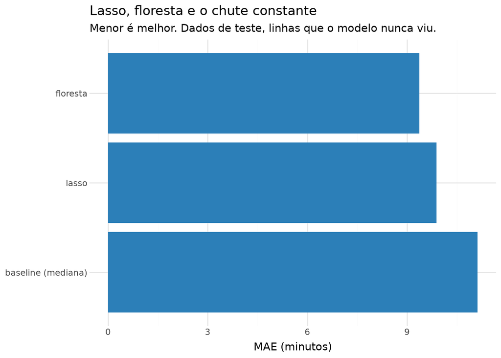

Figura 1: Erro médio absoluto no teste, em minutos.

```python
(
    ggplot(
        resultados.query("particao == 'teste'"),
        aes("reorder(modelo, -mae)", "mae / 60"),
    )
    + geom_col(fill="#2c7fb8")
    + coord_flip()
    + labs(
        title="Lasso, floresta e o chute constante",
        subtitle="Menor é melhor. Dados de teste, linhas que o modelo nunca viu.",
        x="",
        y="MAE (minutos)",
    )
    + theme_minimal()
)
```

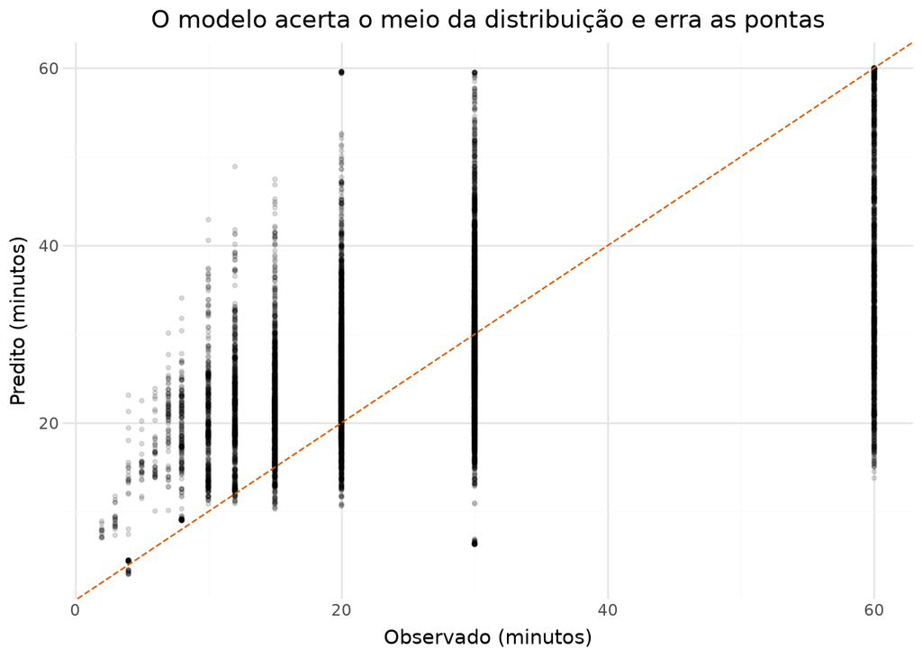

Figura 2: Observado contra predito, floresta aleatória, dados de teste.

```python
comparacao = pd.DataFrame(
    {
        "observado": y_teste.to_numpy() / 60,
        "predito": busca_floresta.best_estimator_.predict(X_teste) / 60,
    }
)

(
    ggplot(comparacao, aes("observado", "predito"))
    + geom_point(alpha=0.12, size=0.8)
    + geom_abline(intercept=0, slope=1, linetype="dashed", color="#d95f02")
    + labs(
        title="O modelo acerta o meio da distribuição e erra as pontas",
        x="Observado (minutos)",
        y="Predito (minutos)",
    )
    + theme_minimal()
)
```

## O que ler nessa tabela

1. **Os dois modelos ganham do baseline**, mas por pouco. O gargalo não é o algoritmo, são os dados: falta demanda, falta contrato de operação.
2. **A floresta ganha do lasso no teste**, e ganha muito mais no treino. Essa distância entre treino e teste é sobreajuste, e é o preço de um modelo flexível.
3. **O R² do baseline é negativo.** Não é bug: o R² compara com prever a *média*, e o baseline prevê a *mediana*, que é o chute constante certo sob MAE. Métrica e baseline precisam ser escolhidos juntos.

**ImportanteSe for comparar com o relatório em R**

O `r2_score` do scikit-learn é `1 - SQE/SQT` e pode ficar negativo. O `yardstick::rsq()` do R é o **quadrado da correlação**, e com um baseline constante devolve `NA`. O equivalente exato do `r2_score` é o `yardstick::rsq_trad()`. Quando os R² de dois relatórios não batem, é aqui que costuma estar a diferença.

**DicaDiferenças com o repositório do lab**

O repositório `lab2-sptrans` faz duas coisas a mais que este documento: modela o alvo em escala logarítmica, com `TransformedTargetRegressor`, e usa `HistGradientBoostingRegressor` como padrão. Aqui ficamos no lasso e na floresta para a comparação com o R ficar direta.

## Salvar o modelo

```python
import joblib

joblib.dump(busca_floresta.best_estimator_, "modelo_floresta.joblib")

# em produção, o objeto recebe DataFrame cru e devolve predição:
modelo = joblib.load("modelo_floresta.joblib")
modelo.predict(X_teste.head())
```

Se o objeto salvo **não** aceitar um `DataFrame` cru, é sinal de que alguma transformação ficou fora do `Pipeline`. Esse é o teste que separa um modelo que vai para produção de um que só funciona no notebook.